# Repeat axis lines on facet panels

Stefan McKinnon Edwards sme@iysik.com

2025-09-04

ggplot2 offers the fantastic option for displaying complex data in forms of ‘many multiple’, i.e. the facets. From the example of `facet_grid`:

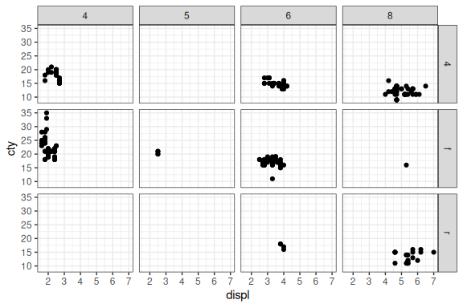

Faceting works quite well in its default form. When the panel’s borders are drawn, nothing lacks.

```r
p <- ggplot(mpg, aes(displ, cty)) + geom_point()
p + facet_grid(drv ~ cyl) + theme_bw()
```

In the above example, the panel’s borders are drawn with the default settings of `theme_bw()`.

If we desire the axis lines, such as those given in this package, the distinction of the panels disappears.

```r
library(lemon)
p <- p + coord_capped_cart(bottom='both', left='both') +
  theme_bw() + theme(panel.border=element_blank(), axis.line=element_line())
p + facet_grid(drv ~ cyl)
```

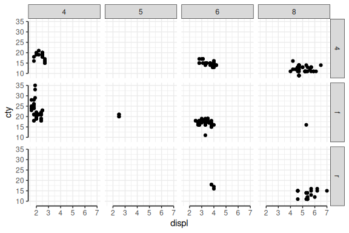

The optimised axis lines are gone from inner panels.

The above example is re-created below with both left- and bottom-axis lines repeated.

```r
library(ggh4x)
p + facet_grid2(drv ~ cyl, axes = TRUE, remove_labels = TRUE) +
  coord_capped_cart(bottom='both', left='both') +
  theme_bw() + theme(panel.border=element_blank(), axis.line=element_line())
```

```
## ℹ Adding new coordinate system, which will replace the existing one.
```

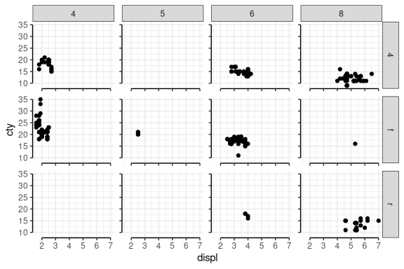

## Keeping (some) labels

In the following example, we change the facet from a grid to being wrapped on the interaction of `drv` and `cyl`, *and add free scaling on y-axis*. `facet_wrap` would normally print the y-axis tick labels for each panel, but still ignores the x-axis.

```r
p + facet_wrap(~ interaction(cyl, drv), scales='free_y')
```

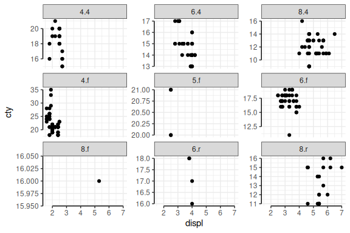

`facet_wrap` keeps y-axis label ticks with `scales='free_y'`.

A work around by keeping both axes free scale, and fixing the x-axis with either `scale_x_continuous` or limits in `cord_*`, but the same x-axis tick labels are repeated. And this is a bit tedious.

```r
p + facet_wrap(~ interaction(cyl, drv), scales='free') +
  coord_capped_cart(bottom='both', left='both', xlim=c(2,7))
```

```
## ℹ Adding new coordinate system, which will replace the existing one.
```

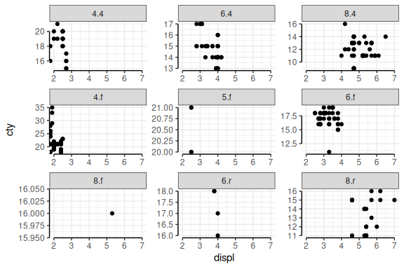

X-axis is entirely fixed, and the plot is littered with x-axis tick labels.

We can specify which *inner* labels to keep with `facet_rap2(..., remove_labels)` . The default is to *keep* all labels, but we can specify to remove all “x” or all “y”.

```r
p + facet_wrap2(~ interaction(cyl, drv), scales = 'free_y', axes = TRUE, remove_labels = "x")
```

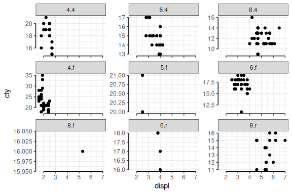

## Examples

There are many possibilities. Examples given below (but not executed), and they might not be pretty.

```r
p + facet_wrap2(~ interaction(cyl, drv), scales = 'free_y', axes = TRUE, remove_labels = FALSE)
p + facet_wrap2(~ interaction(cyl, drv), scales = 'free_y', axes = TRUE, remove_labels = "y")
p + facet_wrap2(~ interaction(cyl, drv), scales = 'free_y', axes = TRUE, remove_labels = "x")
p + scale_x_continuous(sec.axis = dup_axis()) +
  facet_wrap2(~ interaction(cyl, drv), scales = 'free_y', axes = TRUE, remove_labels = FALSE)
```

## Translating between lemon’s and ggh4x’ facets

| lemon | ggh4x |
| --- | --- |
| `facet_rep_wrap(...)` | `facet_wrap2(...)` |
| `facet_rep_grid(...)` | `facet_grid2(...)` |
| `repeat.tick.labels` | `remove_labels,` only “none”, `FALSE`, “x”, “y”, “all” or `TRUE` |
| (None) | `axes`, only “margin”, `FALSE`, “x”, “y”, “all” or `TRUE` |